# bassin_report

## Identification, quantification and analysis of observable anthropogenic debris along swiss river and lakes (IQAASL)

IQAASL is a project sponsored by the Swiss Federal Office for the Environment to quantify shoreline trash along swiss lakes and rivers. Multiple small scale **litter surveys** are completed at different locations within a designated survey area. For the year 2020/2021 the survey areas were defined by the municipalities that border the Aare, Rhône, Ticino and Linth/Limmat rivers and any lakes or rivers that contribute.

### What is a litter survey?

A litter survey is the **identification and count of all anthropogenic objects found within a delimited area**, in this study all surveys were bordered on one side by water (a river or lake). Each object is placed into one of 260 categories¹. The location, date, survey dimensions and the total number of objects in each category is noted.

#### Purpose of the surveys

The survey results help ALL stakeholders identify the items that make up the mass of trash found in the natural environment and where those objects are most likely to be found. The surveys answer the following questions:

- What items are found?
  - The most abundant objects from the water feature and the survey area sorted by total object count
- How much is found ? (total weights and item counts)
  - Total object count, total weight and weight of plastics
- How often are these items found?
  - How often the most abundant items were identified
- Where do you find the most?
  - Pieces of trash per meter (pcs/m): the ratio of number of objects found to the length of the shoreline for each survey location

These are the most frequently asked questions and should be considered in the context of mitigation or reduction strategies.

#### Assumptions:

- The more trash there is on the ground the more a person is likely to find
- **The survey results represent the minimum amount of trash at that site**
- For each survey: finding one item does not effect the chance of finding another

#### Purpose of this report

Summarize the results for the survey area and define the magnitude of those results with respect to the water features within the survey area and all other survey areas.

#### Contents of this report

Scope: description of survey area

- survey locations
- lakes and rivers
- municipalities and effected population

Survey dimensions: locations, aggregated totals

- weights and measures: cumulative
- weights and measures: cumulative by water feature
- survey totals by location: pcs/m by date
- material type: % of total

Trash removed: the most common objects

- the most common objects definition
- the most abundant objects
- objects found in at least half the surveys
- the most common objects
  - median pcs/m
  - fail rates
  - association with land use attributes

Annex

- surveyors
- survey location coordinates
- itemized list of objects removed

### More information

For more information about the project visit [project home](https://www.plagespropres.ch/).

If you would like more information about this survey area please contact:

1. Swiss federal office for the environment - Municipal waste section
2. analyst@hammerdirt.ch

The Aare survey area

### Survey locations and municipalities

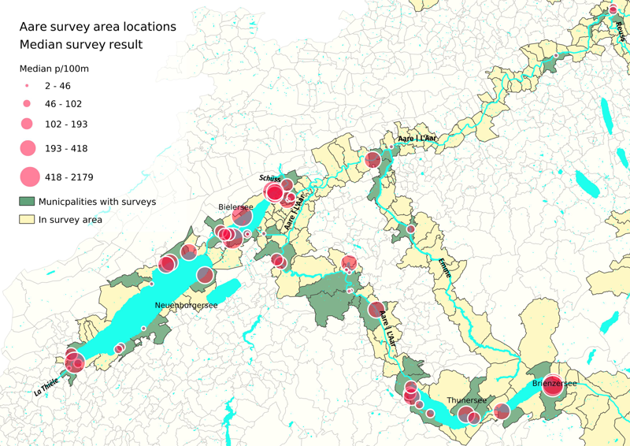

For the period between 2020-03 and 2021-05, 13,816 objects were removed and identified in the course of 139 surveys. Those surveys were conducted at 51 different locations. There are 35 different municipalities represented in these results.

*The lakes in this report:*

Bielersee, Brienzersee, Neuenburgersee, Thunersee

*The rivers in this report:*

Aare, Aare|Nidau-Büren-Kanal, Emme, La Thièle, Schüss

*The municipalities in this report:*

Aarau, Beatenberg, Bern, Biel/Bienne, Boudry, Brienz (BE), Brugg, Brügg, Burgdorf, Bönigen, Cheyres-Châbles, Cudrefin, Erlach, Estavayer, Gals, Gebenstorf, Grandson, Hauterive (NE), Kallnach, Köniz, Le Landeron, Ligerz, Luterbach, Lüscherz, Neuchâtel, Nidau, Port, Rubigen, Solothurn, Spiez, Thun, Unterseen, Vinelz, Walperswil, Yverdon-les-Bains

### The characteristics of the survey locations

The Office fédéral de la statistique provides the 'Statistique de superficie', a grid of points 100m x 100m that covers Switzerland. Each point is assigned one of 72 different land use categories. This grid, as well as the relevant map layers from swissTLMRegio are the basis of determining these values. River discharge points and the length of streets is extracted from the relevant map layer using QGIS.

The land use mix within 1500 meters around each survey location was evaluated for the following criteria:

1. % of surface area attributed to buildings
2. % of surface area left to woods
3. % of surface area attributed to outdoor activities
4. % of surface area attributed to aggriculture
5. length in meters of all roadways
6. number of river discharge intersections

The data for the first four attributes was taken from the Statistique suisse de superficie using the data for the survey 2013/18 (AS1827). The points representing the different land use attributes were added together and divided by the total number of points within the 1500m buffer **not attributed to a water feature**. The street length was calculated using the streets layer from swissTLMRegio.

The number of river discharge intersections is the number of streams/rivers/canals that empty into the lake of interest within 1500m of the survey location. This information is obtained by intersecting the streams layer with the lakes layer from swissTLMRegio.

See the section on calculating land use for more details.

### Land use profile of the survey locations

The distribution of the number of surveys completed at the different land use rates. The land use is reported as the percent of total area attributed to each land use category within a 1500m radius of the survey location. Streets are reported as the total number of kilometers of streets within the 1500m radius. Intersects is also an ordinal ranking of the number of rivers/canals that intersect a lake within 1500m of the survey location.

*Aare survey area land use features of the survey locations*

*distribution of samples with respect to land use*

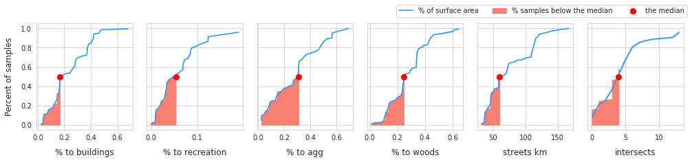

#### Choosing survey sites

The survey locations were chosen based on the following criteria:

1. Data from previous surveys (SLR, MCBP)
2. Year round safe access
3. Within 30 minutes walking distance from nearest public transport

The survey locations represent the land use conditions accesible to approximateley 493,799 people and add to the results from previous projects that used a similar protocol. For more information see the document *Survey site selection and criteria*.

top

### Cumualative totals by water feature

*table of results: water features of the Aare survey area*

*m² and meters is the cumulative sum of all the surveys*

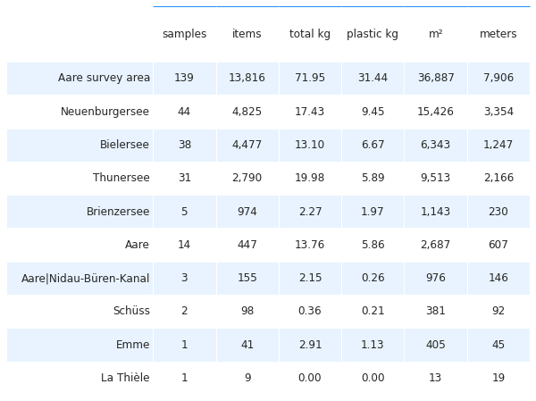

### Survey totals pieces per meter

*Aare survey area, 2020-03 through 2021-05, n=139*

*Values greater than 384.0p/50m 98% not shown.*

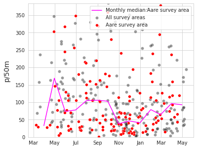

*Summary of survey totals Aare survey area*

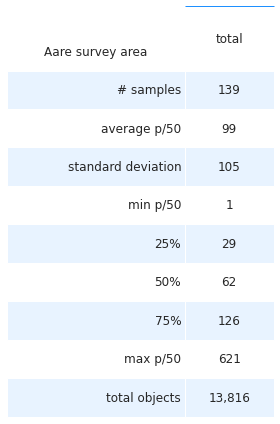

*Material type and percent of total Aare survey area*

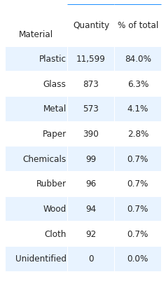

top

### The most common objects

The most common objects are **the ten most abundant by quantity found** or **any object that was indentified in at least 50% of all the surveys**. In this way a greater portion of the material is accounted for and objects that are found regularly but in small quantities are not overlooked.

*Aare survey area most common objects: fail rate > 50% and/or top ten by quantity*

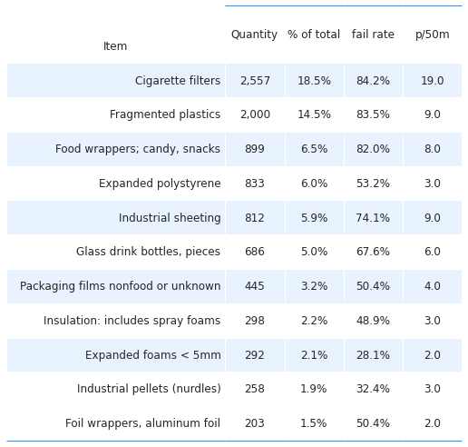

top

*Aare survey area most common objects: average p/50m*

*All water features and samples*

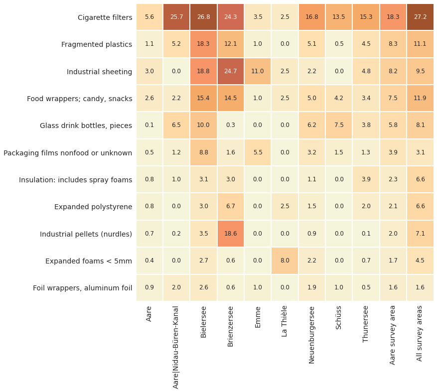

### Association of the most common objects to land use profile

Land use is a method to differentiate survey sites in other ways besides the amount of trash collected. The land use mix is a unique representation of the type and amplititude of econmic activity around the survey location. The key indicators from the survey results are compared against the land use rates for a radius of 1500m from the survey location.

#### Land use map of the survey area:

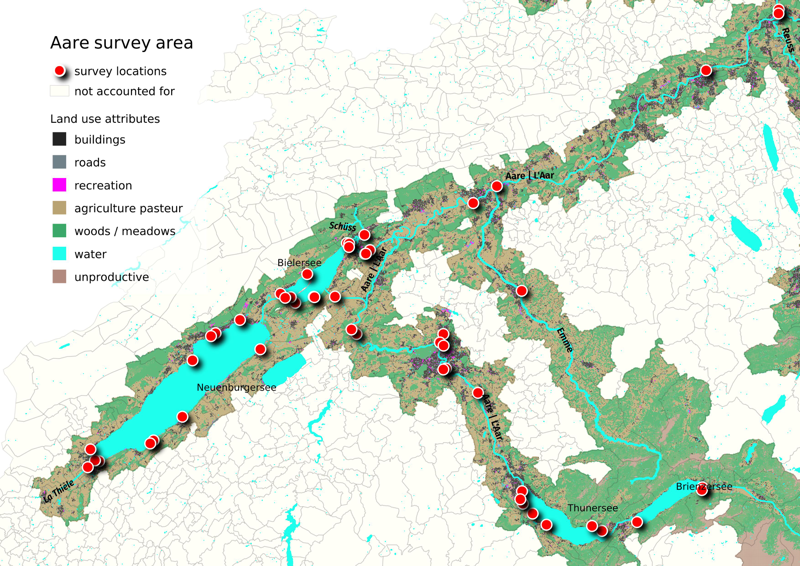

#### Ranked correlation of survey results to land use attributes

This is a test to determine if there is a statistically significant relationship between land use and beach-litter-survey results.

The method used is the Spearman's $\rho$ or *Spearmans ranked correlation coefficient*. The test results are evaluated at p<0.05 for all valid samples in the survey area.

1. Red/rose is a postitive association
2. Yellow is a negative association
3. White means that p>0.05, there is no statisitical basis to assume an association

An association is a relationship between the survey results and the land use attributes that is unlikely due to chance. The magnitude of the relationship is not defined and it is not linear.

*Aare survey area ranked correlation of most common objects to land use profile.*

*For all all surveys on lakes: if p>0.05 = white, if p < 0.05 and $\rho$ > 0 = red, if p < 0.05 and $\rho$ < 0 = yellow*

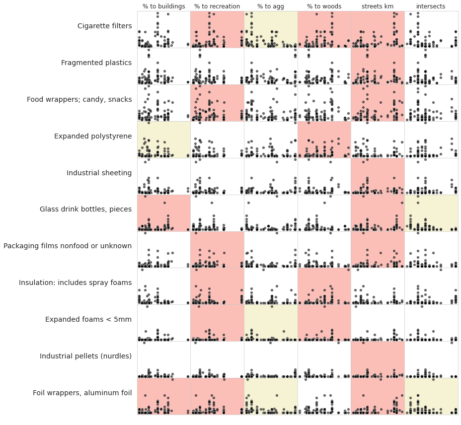

**Interpreting results**

The association results should allways be considered in conjuction with the number of samples.

A positive association means that the land use attribute or feature had increased survey results when compared to other locations. This may be due to a covariance of attributes, either way **a positive association is a signal that the survey locations are near a zone of accumulation or a source**. This signal should be assessed along with the other key indicators at the responsible administrative level.

A negative association means that the land use feature or attribute does not facilitate the accumulation of the object. This result is common for aggricultural areas and woods on the national level. **A negative association is a signal that the locations are not a zone of accumulation for the object**.

No association means that the land use attribute or feature had no accumulating effect on the survey results for that object. The fail rate of the objects with none or few associations should be consulted, especially when considering the most common objects:

1. Objects that have few associations and a high fail rate are ubiquitous
2. Objects that have few associations, low fail rate and high pcs/m maybe close to a source

top

### Utility of the objects found

The utility type is based on the utilisation of the object prior to it being discarded. Objects that are found are placed into to one of the 260 categories. Those categories are grouped according to utilisation.

For example, a piece of plastic could be placed into the category 'Fragmented plastics', depending on its size. However, a piece of plastic that was once a bucket and we know this because we are familiar with either the brand or the product or if we recognize it as a piece of a bucket it is placed in the code for buckets<sup>13</sup>.

- **wastewater**: items released from water treatment plants includes items likely toilet flushed
- **micro plastics (< 5mm)**: fragmented plastic items and pre-production plastic resins
- **infrastructure**: items related to construction and maintenance of all infratructure items
- **food and drink**: primarily single use plastic items related to consuming food and drinks outdoors
- **agriculture**: primarily industrial sheeting includes mulch films
- **tobacco**: primarily cigarette ends includes all smoking related material
- **recreation**: includes fishing, hunting, boating and beach related objects, excludes food, drink and tobacco items
- **packaging non food and drink**: packaging or wrapping material not identified as food, drink nor tobacco related
- **plastic fragments**: foam and plastic fragments of indeterminate origin and use
- **personal items**: accessories, hygiene and clothing related

<sup>13</sup> See the annex for the complete list of objects identified, includes category and group classification - the code for a buckets is G57

*utility of objects found: % of total by water feature*

*fragmented objects with no clear identification remain classified by size*

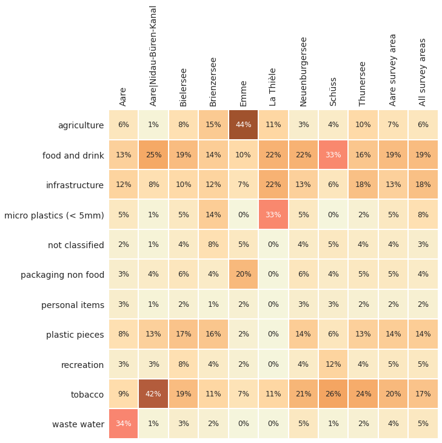

*utility of objects found: p/50m*

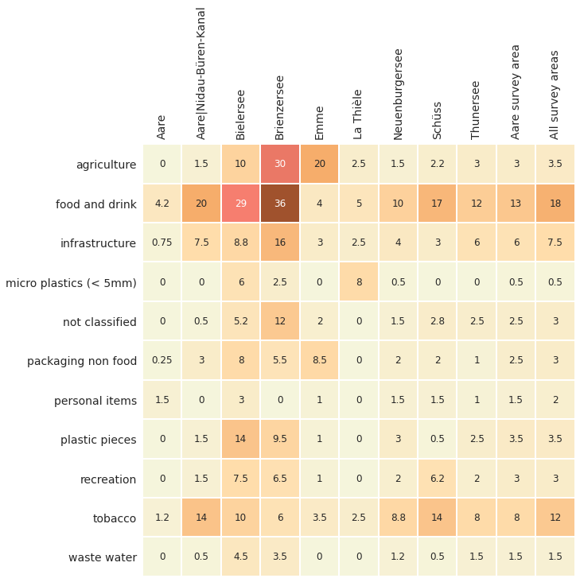

### More information

Contact hammerdirt.ch for any questions about the content of this report. If you would like a report for your municipality contact the Swiss federal office for the environment: Municipal waste section.

Have a great day

**This project was made possible by the Swiss federal office for the environment.**

> Love what you do. ❤️

*roger@hammerdirt.ch* pushed the run button on 2021-07-21.  
This document originates from https://github.com/hammerdirt-analyst/IQAASL-End-0f-Sampling-2021 all copyrights apply.

top

### Annex

1. surveyors
2. Survey location GPS
3. Inventory of all objects removed

annex

#### IQAASL surveyors

Hammerdirt staff:

1. Shannon Erismann, field operations manager
2. Helen Kurukulasuriya, surveyor
3. Débora Carmo, surveyor
4. Bettina Siegenthaler, surveyor
5. Roger Erismann, surveyor

Participating organizations:

1. Precious plastic leman
2. Association pour la sauvetage du Léman
3. Geneva international School
4. Solid waste management: École polytechnique fédéral Lausanne

Annex

### Survey locations

| slug | latitude | longitude | city | population | streets | % to buildings |
| --- | --- | --- | --- | --- | --- | --- |
| aare-port | 47.116170 | 7.269550 | Port | 3695 | 120308 | 0.296623 |
| schutzenmatte | 47.057666 | 7.634001 | Burgdorf | 16420 | 117484 | 0.294032 |
| la-petite-plage | 46.785054 | 6.656877 | Yverdon-les-Bains | 30157 | 72127 | 0.374419 |
| weissenau-neuhaus | 46.676583 | 7.817528 | Unterseen | 5751 | 46161 | 0.041420 |
| evole-plage | 46.989477 | 6.923920 | Neuchâtel | 33489 | 113865 | 0.418546 |
| oberi-chlihochstetten | 46.896025 | 7.532114 | Rubigen | 2929 | 75212 | 0.155096 |
| plage-de-serriere | 46.984850 | 6.913450 | Neuchâtel | 33489 | 103501 | 0.461111 |
| mullermatte | 47.133339 | 7.227907 | Biel/Bienne | 55159 | 109589 | 0.279707 |
| bielersee_vinelz_fankhausers | 47.038398 | 7.108311 | Vinelz | 867 | 58476 | 0.163522 |
| erlach-camping-strand | 47.047159 | 7.097854 | Erlach | 1385 | 38782 | 0.146953 |
| gummligrabbe | 46.989290 | 7.250730 | Kallnach | 1920 | 58975 | 0.047619 |
| mannewil | 46.996382 | 7.239024 | Kallnach | 1920 | 68282 | 0.040123 |
| schusspark-strand | 47.146500 | 7.268620 | Biel/Bienne | 55159 | 140814 | 0.468481 |
| plage-de-cheyres | 46.818689 | 6.782256 | Cheyres-Châbles | 2320 | 36327 | 0.146006 |
| thun-strandbad | 46.739939 | 7.633520 | Thun | 43734 | 97174 | 0.681818 |
| oben-am-see | 46.744451 | 8.049921 | Brienz (BE) | 3092 | 58321 | 0.147773 |
| thunersee_spiez_meierd_1 | 46.704437 | 7.657882 | Spiez | 12812 | 45839 | 0.166667 |
| luscherz-plage | 47.047955 | 7.151242 | Lüscherz | 560 | 37311 | 0.078550 |
| strandboden-biel | 47.132510 | 7.233142 | Biel/Bienne | 55159 | 124400 | 0.371634 |
| signalpain | 46.786200 | 6.647360 | Yverdon-les-Bains | 30157 | 83908 | 0.478555 |
| pointe-dareuse | 46.946190 | 6.870970 | Boudry | 6154 | 32333 | 0.198413 |
| nidau-strand | 47.127196 | 7.232613 | Nidau | 6823 | 119591 | 0.422925 |
| spackmatt | 47.223749 | 7.576711 | Luterbach | 3480 | 96389 | 0.251874 |
| camp-des-peches | 47.052812 | 7.074053 | Le Landeron | 4645 | 74173 | 0.192079 |
| delta-park | 46.720078 | 7.635304 | Spiez | 12812 | 56675 | 0.286885 |
| pecos-plage | 46.803590 | 6.636650 | Grandson | 3357 | 59790 | 0.184713 |
| beich | 47.048495 | 7.200528 | Walperswil | 1043 | 67063 | 0.024060 |
| aare_suhrespitz_badert | 47.405669 | 8.066018 | Aarau | 21506 | 132795 | 0.365152 |
| sundbach-strand | 46.684386 | 7.794768 | Beatenberg | 1195 | 40419 | 0.075718 |
| wycheley | 46.740370 | 8.048640 | Brienz (BE) | 3092 | 50844 | 0.100775 |
| aare_koniz_hoppej | 46.934588 | 7.458170 | Köniz | 41784 | 157177 | 0.476119 |
| camping-gwatt-strand | 46.727140 | 7.629620 | Thun | 43734 | 66513 | 0.384804 |
| bern-tiergarten | 46.933157 | 7.452004 | Bern | 133883 | 152308 | 0.461310 |
| la-thiele_le-mujon_confluence | 46.775340 | 6.630900 | Yverdon-les-Bains | 30157 | 116211 | 0.368189 |
| nouvelle-plage | 46.856646 | 6.848428 | Estavayer | 9716 | 52599 | 0.329446 |
| augustmutzenbergstrandweg | 46.686640 | 7.689760 | Spiez | 12812 | 78706 | 0.370732 |
| aare_bern_gerberm | 46.989363 | 7.452098 | Bern | 133883 | 112333 | 0.302053 |
| brugg-be-buren-bsg-standort | 47.122220 | 7.281410 | Brügg | 4390 | 108796 | 0.244868 |
| ruisseau-de-la-croix-plage | 46.813920 | 6.774700 | Cheyres-Châbles | 2320 | 32157 | 0.120690 |
| ligerz-strand | 47.083979 | 7.135894 | Ligerz | 544 | 50825 | 0.118421 |
| hafeli | 46.690283 | 7.898592 | Bönigen | 2536 | 70327 | 0.245238 |
| aare-solothurn-lido-strand | 47.196949 | 7.521643 | Solothurn | 16777 | 86255 | 0.157576 |
| bern-fahrstrasse | 46.975866 | 7.444210 | Bern | 133883 | 135559 | 0.283105 |
| gals-reserve | 47.046272 | 7.085007 | Gals | 827 | 58522 | 0.122402 |
| hauterive-petite-plage | 47.010797 | 6.980304 | Hauterive (NE) | 2623 | 85236 | 0.326754 |
| aare-limmatspitz | 47.501060 | 8.237371 | Gebenstorf | 5414 | 111924 | 0.224684 |
| aare_brugg_buchie | 47.494855 | 8.236558 | Brugg | 11179 | 120295 | 0.288889 |
| luscherz-two | 47.047519 | 7.152829 | Lüscherz | 560 | 39654 | 0.069061 |
| impromptu_cudrefin | 46.964496 | 7.027936 | Cudrefin | 1633 | 36129 | 0.117949 |
| aare_post | 47.116665 | 7.271953 | Port | 3695 | 118708 | 0.284457 |
| aare_bern_scheurerk | 46.970967 | 7.452586 | Bern | 133883 | 167239 | 0.403349 |

Annex

#### Inventory of all items

| code | item | quantity | utility | % of total | fail rate |
| --- | --- | --- | --- | --- | --- |
| G27 | Cigarette filters | 2557 | tobacco | 18.5 | 84.2 |
| Gfrags | Fragmented plastics | 2000 | plastic pieces | 14.5 | 83.5 |
| G30 | Food wrappers; candy, snacks | 899 | food and drink | 6.5 | 82.0 |
| Gfoam | Expanded polystyrene | 833 | infrastructure | 6.0 | 53.2 |
| G67 | Industrial sheeting | 812 | agriculture | 5.9 | 74.1 |
| G200 | Glass drink bottles, pieces | 686 | food and drink | 5.0 | 67.6 |
| G941 | Packaging films nonfood or unknown | 445 | packaging non food | 3.2 | 50.4 |
| G74 | Insulation: includes spray foams | 298 | infrastructure | 2.2 | 48.9 |
| G117 | Expanded foams < 5mm | 292 | micro plastics (< 5mm) | 2.1 | 28.1 |
| G112 | Industrial pellets (nurdles) | 258 | micro plastics (< 5mm) | 1.9 | 32.4 |
| G98 | Diapers - wipes | 258 | waste water | 1.9 | 28.8 |
| G89 | Plastic construction waste | 219 | infrastructure | 1.6 | 49.6 |
| G177 | Foil wrappers, aluminum foil | 203 | food and drink | 1.5 | 50.4 |
| G95 | Cotton bud/swab sticks | 199 | waste water | 1.4 | 48.9 |
| G25 | Tobacco; plastic packaging, containers | 159 | tobacco | 1.2 | 43.9 |
| G904 | Fireworks; rocket caps, exploded parts & packa... | 155 | recreation | 1.1 | 41.7 |
| G156 | Paper fragments | 149 | not classified | 1.1 | 28.1 |
| G178 | Metal bottle caps and lids | 119 | food and drink | 0.9 | 40.3 |
| G106 | Plastic fragments angular <5mm | 104 | micro plastics (< 5mm) | 0.8 | 27.3 |
| G940 | Foamed EVA for crafts and sports | 102 | recreation | 0.7 | 11.5 |
| G213 | Paraffin wax | 98 | recreation | 0.7 | 18.7 |
| G21 | Drink lids | 98 | food and drink | 0.7 | 31.7 |
| G50 | String < 1cm | 96 | recreation | 0.7 | 36.7 |
| G23 | Lids unidentified | 93 | packaging non food | 0.7 | 30.2 |
| G33 | Cups, lids, single use foamed and hard plastic | 87 | food and drink | 0.6 | 35.3 |
| G922 | Labels, bar codes | 87 | packaging non food | 0.6 | 32.4 |
| G186 | Industrial scrap | 82 | infrastructure | 0.6 | 20.9 |
| G35 | Straws and stirrers | 82 | food and drink | 0.6 | 36.0 |
| G24 | Lid/cap rings from plastic bottles/containers | 79 | food and drink | 0.6 | 28.1 |
| G10 | Food containers single use foamed or plastic | 74 | food and drink | 0.5 | 28.8 |

[output cut: 149 more lines]